# HW3_Linear_regression

## HW3 (answer key)

### [NYC property sales](https://www.kaggle.com/new-york-city/nyc-property-sales) : Linear Regression model

Instructor: [Pedram Jahangiry](https://github.com/PJalgotrader)

```python
import numpy as np
import pandas as pd
import matplotlib.pyplot as plt
import seaborn as sns
from sklearn.linear_model import LinearRegression

sns.set()
```

```python
rand_state= 1000
```

### Data Preprocessing

```python
df = pd.read_csv("nyc-rolling-sales_clean.csv")
df.head()
```

|  | BOROUGH | NEIGHBORHOOD | BUILDING CLASS CATEGORY | TAX CLASS AT PRESENT | BUILDING CLASS AT PRESENT | ZIP CODE | RESIDENTIAL UNITS | COMMERCIAL UNITS | TOTAL UNITS | LAND SQUARE FEET | GROSS SQUARE FEET | YEAR BUILT | TAX CLASS AT TIME OF SALE | BUILDING CLASS AT TIME OF SALE | SALE PRICE | SALE DATE | sale_year | sale_month |
| --- | --- | --- | --- | --- | --- | --- | --- | --- | --- | --- | --- | --- | --- | --- | --- | --- | --- | --- |
| 0 | Manhattan | ALPHABET CITY | 07 RENTALS - WALKUP APARTMENTS | 2B | C4 | 10009 | 10 | 0 | 10 | 2272.0 | 6794.0 | 1913 | 2 | C4 | 3936272.0 | 2016-09-23 | 2016 | 9 |
| 1 | Manhattan | ALPHABET CITY | 07 RENTALS - WALKUP APARTMENTS | 2B | C4 | 10009 | 8 | 0 | 8 | 1750.0 | 4226.0 | 1920 | 2 | C4 | 3192840.0 | 2016-09-23 | 2016 | 9 |
| 2 | Manhattan | ALPHABET CITY | 14 RENTALS - 4-10 UNIT | 2A | S3 | 10009 | 3 | 1 | 4 | 1520.0 | 3360.0 | 1910 | 2 | S3 | 3300000.0 | 2016-11-15 | 2016 | 11 |
| 3 | Manhattan | ALPHABET CITY | 22 STORE BUILDINGS | 4 | K4 | 10009 | 0 | 1 | 1 | 1218.0 | 3586.0 | 1899 | 4 | K4 | 3700000.0 | 2016-09-28 | 2016 | 9 |
| 4 | Manhattan | CHELSEA | 07 RENTALS - WALKUP APARTMENTS | 2B | C4 | 10011 | 9 | 0 | 9 | 1566.0 | 6330.0 | 1901 | 2 | C4 | 1583840.0 | 2017-08-31 | 2017 | 8 |

```python
# constructing the numerical variables:
numeric = ["RESIDENTIAL UNITS","COMMERCIAL UNITS","TOTAL UNITS", "LAND SQUARE FEET" , "GROSS SQUARE FEET","SALE PRICE" ]

for col in numeric:
    df[col] = pd.to_numeric(df[col], errors='coerce') # coercing errors to NAs
```

```python
# constructing the categorical variables:
categorical = ["BOROUGH","NEIGHBORHOOD",'BUILDING CLASS CATEGORY', 'TAX CLASS AT PRESENT', 'BUILDING CLASS AT PRESENT','ZIP CODE', 'YEAR BUILT', 'BUILDING CLASS AT TIME OF SALE', 'TAX CLASS AT TIME OF SALE', 'sale_month']

for col in categorical:
    df[col] = df[col].astype("category")
```

```python
list(df.columns)
```

```
['BOROUGH',
 'NEIGHBORHOOD',
 'BUILDING CLASS CATEGORY',
 'TAX CLASS AT PRESENT',
 'BUILDING CLASS AT PRESENT',
 'ZIP CODE',
 'RESIDENTIAL UNITS',
 'COMMERCIAL UNITS',
 'TOTAL UNITS',
 'LAND SQUARE FEET',
 'GROSS SQUARE FEET',
 'YEAR BUILT',
 'TAX CLASS AT TIME OF SALE',
 'BUILDING CLASS AT TIME OF SALE',
 'SALE PRICE',
 'SALE DATE',
 'sale_year',
 'sale_month']
```

```python
# Let's drop the variables that we don't use in our linear regression model

df = df.drop(['sale_year','SALE DATE','TOTAL UNITS'], axis=1)
```

```python
df.info()
```

```
<class 'pandas.core.frame.DataFrame'>
RangeIndex: 30236 entries, 0 to 30235
Data columns (total 15 columns):
BOROUGH                           30236 non-null category
NEIGHBORHOOD                      30236 non-null category
BUILDING CLASS CATEGORY           30236 non-null category
TAX CLASS AT PRESENT              30236 non-null category
BUILDING CLASS AT PRESENT         30236 non-null category
ZIP CODE                          30236 non-null category
RESIDENTIAL UNITS                 30236 non-null int64
COMMERCIAL UNITS                  30236 non-null int64
LAND SQUARE FEET                  30236 non-null float64
GROSS SQUARE FEET                 30236 non-null float64
YEAR BUILT                        30236 non-null category
TAX CLASS AT TIME OF SALE         30236 non-null category
BUILDING CLASS AT TIME OF SALE    30236 non-null category
SALE PRICE                        30236 non-null float64
sale_month                        30236 non-null category
dtypes: category(10), float64(3), int64(2)
memory usage: 1.6 MB
```

```python
df.describe(include='all').T
```

|  | count | unique | top | freq | mean | std | min | 25% | 50% | 75% | max |
| --- | --- | --- | --- | --- | --- | --- | --- | --- | --- | --- | --- |
| BOROUGH | 30236 | 5 | Brooklyn | 11042 | NaN | NaN | NaN | NaN | NaN | NaN | NaN |
| NEIGHBORHOOD | 30236 | 242 | FLUSHING-NORTH | 759 | NaN | NaN | NaN | NaN | NaN | NaN | NaN |
| BUILDING CLASS CATEGORY | 30236 | 38 | 01 ONE FAMILY DWELLINGS | 12473 | NaN | NaN | NaN | NaN | NaN | NaN | NaN |
| TAX CLASS AT PRESENT | 30236 | 9 | 1 | 24441 | NaN | NaN | NaN | NaN | NaN | NaN | NaN |
| BUILDING CLASS AT PRESENT | 30236 | 115 | A1 | 4692 | NaN | NaN | NaN | NaN | NaN | NaN | NaN |
| ZIP CODE | 30236 | 171 | 10314 | 835 | NaN | NaN | NaN | NaN | NaN | NaN | NaN |
| RESIDENTIAL UNITS | 30236 | NaN | NaN | NaN | 1.97053 | 12.587 | 0 | 1 | 1 | 2 | 1844 |
| COMMERCIAL UNITS | 30236 | NaN | NaN | NaN | 0.173039 | 13.0346 | 0 | 0 | 0 | 0 | 2261 |
| LAND SQUARE FEET | 30236 | NaN | NaN | NaN | 3133.58 | 27966.3 | 0 | 1816.5 | 2417 | 3500 | 4.2283e+06 |
| GROSS SQUARE FEET | 30236 | NaN | NaN | NaN | 2440.36 | 23800.2 | 0 | 1208 | 1680 | 2392 | 3.75056e+06 |
| YEAR BUILT | 30236 | 137 | 1920 | 3267 | NaN | NaN | NaN | NaN | NaN | NaN | NaN |
| TAX CLASS AT TIME OF SALE | 30236 | 3 | 1 | 24824 | NaN | NaN | NaN | NaN | NaN | NaN | NaN |
| BUILDING CLASS AT TIME OF SALE | 30236 | 115 | A1 | 4687 | NaN | NaN | NaN | NaN | NaN | NaN | NaN |
| SALE PRICE | 30236 | NaN | NaN | NaN | 793820 | 594725 | 10001 | 436000 | 630000 | 940000 | 3.995e+06 |
| sale_month | 30236 | 12 | 6 | 2931 | NaN | NaN | NaN | NaN | NaN | NaN | NaN |

```python
df.isnull().sum() / len(df)
# Alternatively we could use isnull() from pandas.
# pd.isnull(df).sum()
```

```
BOROUGH                           0.0
NEIGHBORHOOD                      0.0
BUILDING CLASS CATEGORY           0.0
TAX CLASS AT PRESENT              0.0
BUILDING CLASS AT PRESENT         0.0
ZIP CODE                          0.0
RESIDENTIAL UNITS                 0.0
COMMERCIAL UNITS                  0.0
LAND SQUARE FEET                  0.0
GROSS SQUARE FEET                 0.0
YEAR BUILT                        0.0
TAX CLASS AT TIME OF SALE         0.0
BUILDING CLASS AT TIME OF SALE    0.0
SALE PRICE                        0.0
sale_month                        0.0
dtype: float64
```

### Plotting the NA values

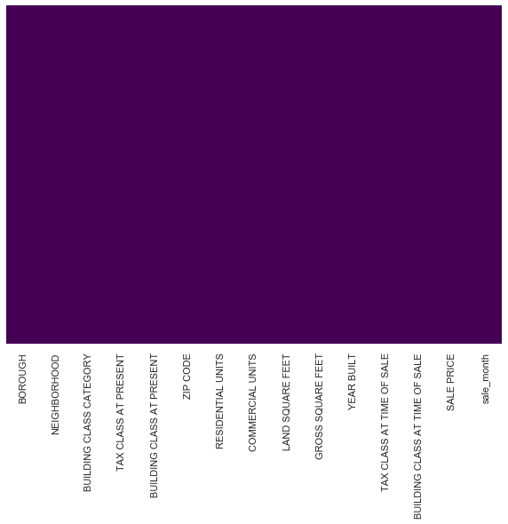

```python
plt.figure(figsize=(10,7))
sns.heatmap(df.isnull(),yticklabels=False,cbar=False,cmap='viridis')
```

### Data visualization

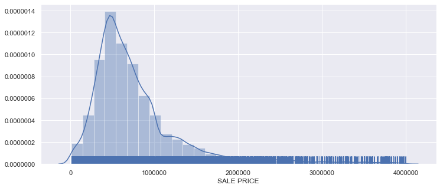

```python
plt.figure(figsize=(12,5))
sns.distplot(df['SALE PRICE'], bins=30 , rug=True)
plt.show()
```

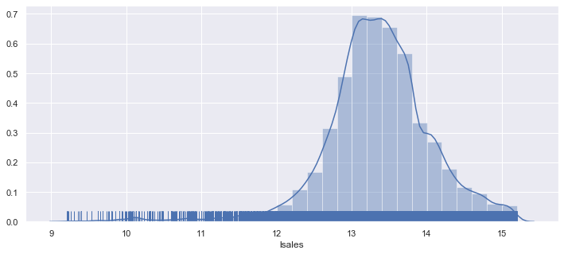

```python
# Need to do log transformation to avoid potential heteroskedasticity
plt.figure(figsize=(12,5))
df['lsales']= np.log(df['SALE PRICE'])
sns.distplot(df['lsales'], bins=30 , rug=True)
plt.show()
```

### Dealing with dummy variables

```python
df2 = pd.get_dummies(df, drop_first=True)
df2.shape
# Look at that, we have 843 features!!
```

```
(30236, 843)
```

```python
#list(df2.columns)
```

### Defining the variables and splitting the data

```python
y = df2['lsales']
X = df2.drop(['lsales','SALE PRICE'], axis=1) # becareful inplace= False

from sklearn.model_selection import train_test_split
X_train, X_test, y_train, y_test = train_test_split(X, y, test_size=0.2, random_state=rand_state)
```

```python
X_train.head()
```

|  | RESIDENTIAL UNITS | COMMERCIAL UNITS | LAND SQUARE FEET | GROSS SQUARE FEET | BOROUGH_Brooklyn | BOROUGH_Manhattan | BOROUGH_Queens | BOROUGH_Staten Island | NEIGHBORHOOD_ALPHABET CITY | NEIGHBORHOOD_ANNADALE | ... | sale_month_3 | sale_month_4 | sale_month_5 | sale_month_6 | sale_month_7 | sale_month_8 | sale_month_9 | sale_month_10 | sale_month_11 | sale_month_12 |
| --- | --- | --- | --- | --- | --- | --- | --- | --- | --- | --- | --- | --- | --- | --- | --- | --- | --- | --- | --- | --- | --- |
| 15308 | 1 | 1 | 2500.0 | 1024.0 | 0 | 0 | 1 | 0 | 0 | 0 | ... | 1 | 0 | 0 | 0 | 0 | 0 | 0 | 0 | 0 | 0 |
| 30014 | 2 | 0 | 4800.0 | 2268.0 | 0 | 0 | 0 | 1 | 0 | 0 | ... | 0 | 0 | 0 | 0 | 0 | 0 | 0 | 0 | 1 | 0 |
| 22437 | 3 | 0 | 4000.0 | 2075.0 | 0 | 0 | 1 | 0 | 0 | 0 | ... | 0 | 0 | 0 | 0 | 0 | 0 | 0 | 0 | 0 | 0 |
| 14045 | 2 | 0 | 1310.0 | 1500.0 | 1 | 0 | 0 | 0 | 0 | 0 | ... | 0 | 0 | 0 | 0 | 0 | 0 | 0 | 0 | 0 | 1 |
| 29096 | 1 | 0 | 2821.0 | 920.0 | 0 | 0 | 0 | 1 | 0 | 0 | ... | 0 | 0 | 0 | 0 | 0 | 0 | 1 | 0 | 0 | 0 |

5 rows × 841 columns

## Linear Regression with Scikit-Learn

#### Note: with sklearn, we don't need to add constants mannually.

```python
sklearn_reg = LinearRegression()
```

```python
sklearn_reg.fit(X_train, y_train)
```

```
LinearRegression(copy_X=True, fit_intercept=True, n_jobs=None, normalize=False)
```

### Generating results

```python
# The coefficients of the regression; there are +800 explanatory variables here! if you are supercurious, you can look at these coefficients by running the follwoing line.
#sklearn_reg.coef_
```

```python
# The intercept of the regression
sklearn_reg.intercept_
```

```
13.723085135513399
```

```python
# The R-squared of the regression
sklearn_reg.score(X_train,y_train)
```

```
0.5060621704480539
```

```python
# If we want to find the Adjusted R-squared we can do so by knowing the R2, the # observations, the # features
R2 = sklearn_reg.score(X_train,y_train)
n = X_train.shape[0]
p = X_train.shape[1]

# We find the Adjusted R-squared using the formula
adjusted_R2 = 1-(1-R2)*(n-1)/(n-p-1)
adjusted_R2
```

```
0.4882688990245473
```

```python
# Let's create a new data frame with the names of the features
reg_summary = pd.DataFrame(data = X_train.columns, columns=['Features'])
reg_summary ['Coefficients'] = sklearn_reg.coef_
#reg_summary
```

### Testing

Once we have trained and fine-tuned our model, we can proceed to testing it. Testing is done on a dataset that the algorithm has never seen

```python
# Using our sklearn reg. Remember: sklearn tends to convert everything into arrays rather than data frame. Thus, the head(4) does not work here.
sklearn_reg.predict(X_test)[0:4]
```

```
array([13.71969669, 13.08513184, 13.23976613, 13.14711124])
```

```python
y_hat_test = sklearn_reg.predict(X_test)
log_predictions = pd.DataFrame( {'Actuals':y_test , 'Predictions': y_hat_test})
predictions = np.exp(log_predictions)
```

## Question 1:

Use LinearRegression() model from Sklearn package and report the RMSE_te (RMSE of the test set) of your model. At this stage I only want you to work on a linear fit.

```python
# If you are using Sales price:
predictions.head()
```

|  | Actuals | Predictions |
| --- | --- | --- |
| 3767 | 1300000.0 | 9.086331e+05 |
| 24270 | 540000.0 | 4.817265e+05 |
| 27718 | 650000.0 | 5.622861e+05 |
| 6232 | 390000.0 | 5.125283e+05 |
| 11161 | 900000.0 | 1.106873e+06 |

```python
MSE_test = round(np.mean(np.square(predictions['Actuals'] - predictions['Predictions'])),2)
RMSE_test = round(np.sqrt(MSE_test),2)
RMSE_test
```

```
473298.25
```

```python
# If you are using Log(Sales price):
log_predictions.head()
```

|  | Actuals | Predictions |
| --- | --- | --- |
| 3767 | 14.077875 | 13.719697 |
| 24270 | 13.199324 | 13.085132 |
| 27718 | 13.384728 | 13.239766 |
| 6232 | 12.873902 | 13.147111 |
| 11161 | 13.710150 | 13.917049 |

```python
MSE_test = round(np.mean(np.square(log_predictions['Actuals'] - log_predictions['Predictions'])),2)
RMSE_test = round(np.sqrt(MSE_test),2)
RMSE_test
```

```
0.54
```

## Question 2:

Estimate the RMSE_te using K-Fold Cross Validation technique (try K=5 and K=10). Compare this RMSE_CV with the RMSE_te from part 1. Make some comparison comments about RMSE_te and RMSE_CV.

```python
from sklearn.model_selection import cross_val_score
import sklearn.metrics
```

```python
model= LinearRegression()
```

```python
RMSE_CV=[]
K = (5,10)
for i in K:
    NMSE = cross_val_score(estimator = model, X = X_train, y = y_train, cv = i , scoring="neg_mean_squared_error" )
    RMSE_CV.append(round(np.sqrt(-NMSE).mean(),2))

RMSE_CV_df = pd.DataFrame(K, columns=['K'])
RMSE_CV_df['RMSE_CV']=RMSE_CV

RMSE_CV_df
```

|  | K | RMSE_CV |
| --- | --- | --- |
| 0 | 5 | 0.75 |
| 1 | 10 | 0.57 |

As we can see from the table above, the RMSE_CV is greater than the RMSE_te= 0.54. This means that our CV RMSE is overestimating the RMSE_te. This overestimation is way bigger for 5-fold versus 10-fold cross validation.

## Question 3: Bonus Exercise

Incorporate non-linearity in the feature space (pick the variables that you think it make most sense to have them as polynomial features in the model) and calculate the new RMSE_te. Use cross validation and elbow method to figure out the optimal polynomial degree. Were you able to improve the performance of your model? Is this improvement worth losing interpretability ?

for this part, we are going to pick "**LAND SQUARE FEET**" as our candidate for incorporating non-linearity.

```python
from sklearn.preprocessing import PolynomialFeatures
```

```python
poly= PolynomialFeatures(degree=3)
```

```python
X_poly= pd.DataFrame(poly.fit_transform(np.array(df['LAND SQUARE FEET']).reshape(-1,1)))
X_poly.head()
```

|  | 0 | 1 | 2 | 3 |
| --- | --- | --- | --- | --- |
| 0 | 1.0 | 2272.0 | 5161984.0 | 1.172803e+10 |
| 1 | 1.0 | 1750.0 | 3062500.0 | 5.359375e+09 |
| 2 | 1.0 | 1520.0 | 2310400.0 | 3.511808e+09 |
| 3 | 1.0 | 1218.0 | 1483524.0 | 1.806932e+09 |
| 4 | 1.0 | 1566.0 | 2452356.0 | 3.840389e+09 |

Working with sklearn, we don't need to add constant. So we need to drop the first column in X_poly. Then we can merge this data frame to our original df. However, we have to remove the 'LAND SQUARE FEET' column from our final data frame to avoid perfect collinearity.

```python
X_poly.drop(0, axis=1, inplace=True)
X_poly.head()
```

|  | 1 | 2 | 3 |
| --- | --- | --- | --- |
| 0 | 2272.0 | 5161984.0 | 1.172803e+10 |
| 1 | 1750.0 | 3062500.0 | 5.359375e+09 |
| 2 | 1520.0 | 2310400.0 | 3.511808e+09 |
| 3 | 1218.0 | 1483524.0 | 1.806932e+09 |
| 4 | 1566.0 | 2452356.0 | 3.840389e+09 |

```python
new_df = pd.concat([X_poly,df],axis=1 )
new_df.drop('LAND SQUARE FEET',axis=1,inplace=True)
new_df.shape
```

```
(30236, 18)
```

```python
new_df = pd.get_dummies(new_df, drop_first=True)
new_df.shape
```

```
(30236, 845)
```

```python
y = new_df['lsales']
X = new_df.drop(['lsales','SALE PRICE'], axis=1) # becareful inplace= False

from sklearn.model_selection import train_test_split
X_train, X_test, y_train, y_test = train_test_split(X, y, test_size=0.2, random_state=rand_state)
```

```python
sklean_reg = LinearRegression()
sklearn_reg.fit(X_train, y_train)
y_pred = sklearn_reg.predict(X_test)
```

```python
RMSE_te = round(np.sqrt(np.mean(np.square(y_test-y_pred))),2)
RMSE_te
```

```
0.72
```

```python
NMSE = cross_val_score(estimator = sklean_reg, X = X_train, y = y_train, cv = 5 , scoring="neg_mean_squared_error" )
RMSE_CV=round(np.sqrt(-NMSE).mean(),2)
RMSE_CV
```

```
1.16
```

As we can see, it seems that polynomial model with degree 3 is worse than our simple model in part 1. (RMSE_te 0.72 vs 0.54).

Now let's figure out what is the best polynomial degree using elbow method.

```python
d = 4
RMSE_te_poly=[]
RMSE_CV_poly=[]
for i in range(1,d+1):
    poly= PolynomialFeatures(degree=i)
    X_poly= pd.DataFrame(poly.fit_transform(np.array(df['LAND SQUARE FEET']).reshape(-1,1)))
    X_poly.drop(0, axis=1, inplace=True)
    new_df = pd.concat([X_poly,df],axis=1 )
    new_df.drop('LAND SQUARE FEET',axis=1,inplace=True)
    new_df = pd.get_dummies(new_df, drop_first=True)

    X_train, X_test, y_train, y_test = train_test_split(new_df.drop(['lsales','SALE PRICE'], axis=1), new_df['lsales'], test_size=0.2, random_state=rand_state)
    sklean_reg = LinearRegression()
    sklearn_reg.fit(X_train, y_train)
    RMSE_te_poly.append(round(np.sqrt(np.mean(np.square(y_test-sklearn_reg.predict(X_test)))),2))
    RMSE_CV_poly.append(np.sqrt(-cross_val_score(estimator = sklean_reg, X = X_train, y = y_train, cv = 5 , scoring="neg_mean_squared_error" ).mean()))

output = pd.DataFrame(list(range(1,d+1)), columns=['Poly degree'])
output['RMSE_te']=RMSE_te_poly
output['RMSE_CV']=RMSE_CV_poly
output
```

|  | Poly degree | RMSE_te | RMSE_CV |
| --- | --- | --- | --- |
| 0 | 1 | 0.54 | 0.848361 |
| 1 | 2 | 0.54 | 1.561680 |
| 2 | 3 | 0.72 | 1.467702 |
| 3 | 4 | 0.72 | 15.791716 |

The best polynomial degree is d=1. So we conclude that '**'LAND SQUARE FEET'**' was not our best choice to incorporate non-linearity for.